# CapstoneProject

```python
# ============================================================
# STAGE ML-2: MACHINE LEARNING MODEL DEVELOPMENT
# BLOCK 1: INSTALL AND IMPORT REQUIRED LIBRARIES
# ============================================================

# Install openpyxl for reading Excel workbooks in Google Colab.
!pip install openpyxl -q

# Import NumPy for numerical operations.
import numpy as np

# Import pandas for data loading, cleaning, and manipulation.
import pandas as pd

# Import matplotlib for creating visualizations.
import matplotlib.pyplot as plt

# Import warnings to suppress unnecessary warning messages.
import warnings

# Suppress warning messages to keep the notebook output clean.
warnings.filterwarnings("ignore")

# Import Google Colab file upload utility.
from google.colab import files

# Import train-test split for model validation.
from sklearn.model_selection import train_test_split

# Import K-Fold cross-validation for small-sample validation.
from sklearn.model_selection import KFold, cross_validate

# Import StandardScaler for feature scaling where required.
from sklearn.preprocessing import StandardScaler

# Import Pipeline to combine preprocessing and modelling steps.
from sklearn.pipeline import Pipeline

# Import Linear Regression as the baseline regression model.
from sklearn.linear_model import LinearRegression

# Import Ridge Regression for regularized linear modelling.
from sklearn.linear_model import Ridge

# Import Random Forest Regressor for nonlinear tree-based modelling.
from sklearn.ensemble import RandomForestRegressor

# Import Gradient Boosting Regressor for boosted tree-based modelling.
from sklearn.ensemble import GradientBoostingRegressor

# Import model evaluation metrics for regression performance.
from sklearn.metrics import mean_absolute_error, mean_squared_error, r2_score

# Import Spearman correlation for ranking-quality evaluation.
from scipy.stats import spearmanr

# Set a fixed random seed for reproducibility.
RANDOM_STATE = 42

# Display confirmation that all libraries have been loaded successfully.
print("Block 1 completed: Required libraries imported successfully.")
```

```
Block 1 completed: Required libraries imported successfully.
```

```python
# ============================================================
# STAGE ML-2: MACHINE LEARNING MODEL DEVELOPMENT
# BLOCK 2: UPLOAD AND LOAD THE MODEL-READY EXCEL WORKBOOK
# ============================================================

# Prompt the user to upload the Stage ML-1 model-ready Excel workbook.
uploaded = files.upload()

# Get the uploaded file name automatically.
uploaded_file_name = list(uploaded.keys())[0]

# Display the uploaded file name for confirmation.
print(f"Uploaded file: {uploaded_file_name}")

# Load the Excel workbook so that we can inspect its sheet names.
excel_file = pd.ExcelFile(uploaded_file_name)

# Display all sheet names available in the workbook.
print("Available sheets in the workbook:")
for sheet in excel_file.sheet_names:
    print(f"- {sheet}")

# Load the core state-year modelling dataset.
core_df = pd.read_excel(uploaded_file_name, sheet_name="Model_Ready_Core_StateYear")

# Load the expanded 2022 modelling dataset.
expanded_df = pd.read_excel(uploaded_file_name, sheet_name="Model_Ready_Expanded_2022")

# Display the shape of the core dataset.
print("\nCore modelling dataset shape:")
print(core_df.shape)

# Display the shape of the expanded dataset.
print("\nExpanded 2022 modelling dataset shape:")
print(expanded_df.shape)

# Display the first five rows of the core modelling dataset.
print("\nPreview of core modelling dataset:")
display(core_df.head())

# Display the first five rows of the expanded modelling dataset.
print("\nPreview of expanded 2022 modelling dataset:")
display(expanded_df.head())
```

Upload widget is only available when the cell has been executed in the current browser session. Please rerun this cell to enable.

```
Saving Capstone_Stage_ML1_Model_Ready_Dataset.xlsx to Capstone_Stage_ML1_Model_Ready_Dataset.xlsx
Uploaded file: Capstone_Stage_ML1_Model_Ready_Dataset.xlsx
Available sheets in the workbook:
- ML1_Dashboard
- Model_Ready_Core_StateYear
- Model_Ready_Expanded_2022
- Feature_Dictionary
- Target_Definitions
- Missingness_QC
- Split_Strategy
- ML1_Log

Core modelling dataset shape:
(148, 20)

Expanded 2022 modelling dataset shape:
(37, 26)

Preview of core modelling dataset:
```

|  | state | year | target_beni_core_score | beni_rank_within_year | priority_band_within_year | pupil_teacher_ratio | pupil_classroom_ratio | unqualified_teacher_share | bad_classroom_share | enrolment_per_school | pupil_teacher_ratio_norm | pupil_classroom_ratio_norm | unqualified_teacher_share_norm | bad_classroom_share_norm | enrolment_per_school_norm | matching_grant_million_naira | core_indicator_completeness | split_group | model_ready_flag | source_note |
| --- | --- | --- | --- | --- | --- | --- | --- | --- | --- | --- | --- | --- | --- | --- | --- | --- | --- | --- | --- | --- |
| 0 | Abia | 2018 | 0.281145 | 23 | Medium Need | 16.316241 | 23.249512 | 0.269292 | 0.536944 | 111.945077 | 0.048500 | 0.047917 | 0.469592 | 0.832862 | 0.006852 | 1473.832839 | 1 | TRAIN_2018_2020 | True | Common 2018-2020 UBEC public school indicators |
| 1 | Abia | 2019 | 0.209660 | 26 | Lower Need | 24.730723 | 22.969626 | 0.078421 | 0.530780 | 110.894066 | 0.117433 | 0.045379 | 0.063723 | 0.815784 | 0.005981 | 1519.884079 | 1 | TRAIN_2018_2020 | True | Common 2018-2020 UBEC public school indicators |
| 2 | Abia | 2020 | 0.210734 | 26 | Lower Need | 24.693421 | 23.564608 | 0.077390 | 0.530780 | 113.878252 | 0.117127 | 0.050775 | 0.061531 | 0.815784 | 0.008454 | 0.000000 | 1 | TRAIN_2018_2020 | True | Common 2018-2020 UBEC public school indicators |
| 3 | Abia | 2022 | 0.210275 | 30 | Lower Need | 30.500512 | 30.594456 | 0.114264 | 0.411798 | 279.922289 | 0.164700 | 0.114532 | 0.139941 | 0.486110 | 0.146091 | 0.000000 | 1 | TEST_2022 | True | 2022 UBEC public school indicators with richer... |
| 4 | Adamawa | 2018 | 0.372746 | 16 | Medium Need | 24.037105 | 47.668293 | 0.283406 | 0.545268 | 256.969886 | 0.111750 | 0.269385 | 0.499605 | 0.855926 | 0.127066 | 1473.832839 | 1 | TRAIN_2018_2020 | True | Common 2018-2020 UBEC public school indicators |

```
Preview of expanded 2022 modelling dataset:
```

|  | state | year | target_beni_expanded_score | target_beni_core_score | beni_expanded_rank | beni_core_rank | pupil_teacher_ratio | pupil_classroom_ratio | unqualified_teacher_share | bad_classroom_share | ... | pupil_teacher_ratio_norm | pupil_classroom_ratio_norm | unqualified_teacher_share_norm | bad_classroom_share_norm | enrolment_per_school_norm | nbs_socioeconomic_need_proxy_norm | cv_fold | split_group | model_ready_flag | source_note |
| --- | --- | --- | --- | --- | --- | --- | --- | --- | --- | --- | --- | --- | --- | --- | --- | --- | --- | --- | --- | --- | --- |
| 0 | Abia | 2022 | 0.226964 | 0.213197 | 34 | 33 | 30.500512 | 30.594456 | 0.114264 | 0.411798 | ... | 0.184572 | 0.114532 | 0.163753 | 0.505077 | 0.098051 | 0.295798 | 1 | CV_ONLY_2022 | True | Final 2022 expanded BENI dataset; use 5-fold o... |
| 1 | Adamawa | 2022 | 0.478211 | 0.436265 | 15 | 15 | 31.352943 | 55.448834 | 0.255650 | 0.440142 | ... | 0.193556 | 0.339951 | 0.740143 | 0.586677 | 0.320999 | 0.687942 | 2 | CV_ONLY_2022 | True | Final 2022 expanded BENI dataset; use 5-fold o... |
| 2 | Akwa Ibom | 2022 | 0.449562 | 0.430440 | 17 | 16 | 55.882855 | 50.260242 | 0.102662 | 0.337355 | ... | 0.452090 | 0.292892 | 0.116452 | 0.290766 | 1.000000 | 0.545173 | 3 | CV_ONLY_2022 | True | Final 2022 expanded BENI dataset; use 5-fold o... |
| 3 | Anambra | 2022 | 0.218361 | 0.229421 | 35 | 29 | 21.699372 | 30.019064 | 0.189946 | 0.362361 | ... | 0.091811 | 0.109314 | 0.472285 | 0.362753 | 0.110941 | 0.163061 | 4 | CV_ONLY_2022 | True | Final 2022 expanded BENI dataset; use 5-fold o... |
| 4 | Bauchi | 2022 | 0.539975 | 0.476706 | 10 | 11 | 47.831330 | 72.598058 | 0.128952 | 0.572126 | ... | 0.367231 | 0.495486 | 0.223631 | 0.966644 | 0.330540 | 0.856315 | 5 | CV_ONLY_2022 | True | Final 2022 expanded BENI dataset; use 5-fold o... |

5 rows × 26 columns

## Block Result Reviewed: Upload and Load Workbook

This block ran **successfully**.

The workbook uploaded correctly as **`Capstone_Stage_ML1_Model_Ready_Dataset.xlsx`**, and Colab loaded the expected sheets, including:

- `Model_Ready_Core_StateYear`
- `Model_Ready_Expanded_2022`
- `Feature_Dictionary`
- `Target_Definitions`
- `Split_Strategy`
- `ML1_Log`

The loaded shapes are also exactly what we expected from Stage ML-1:

| Dataset | Shape | Interpretation |
| --- | --- | --- |
| Core modelling dataset | 148 rows × 20 columns | 37 states/FCT across 2018, 2019, 2020, and 2022 |
| Expanded 2022 modelling dataset | 37 rows × 26 columns | One 2022 row for each state/FCT |

The output confirms that the core dataset contains 148 rows and the expanded 2022 dataset contains 37 rows.

## What This Means

This is methodologically correct.

The **core dataset** is suitable for a holdout validation design:

- Train on 2018–2020.
- Test on 2022.

The **expanded dataset** is cross-sectional for 2022 only, so it is correctly suited to:

- 5-fold cross-validation;
- careful interpretation;
- ranking validation rather than strong forecasting claims.

## Important Observation

The preview shows that the actual target column names are:

- `target_beni_core_score`
- `target_beni_expanded_score`

This confirms why the earlier error occurred when the code looked for `beni_core_score`.

The expanded dataset also contains only the combined NBS indicator:

- `nbs_socioeconomic_need_proxy`
- `nbs_socioeconomic_need_proxy_norm`

So we should not expect separate columns like school non-attendance, water deprivation, or sanitation deprivation in the ML workbook. The model should use the available NBS proxy, as already corrected.

## Recommendation

Proceed. This block is clean.

For report documentation, describe it this way:

> The model-ready workbook contains two analytical datasets: a 148-row core state-year dataset for training and 2022 holdout testing, and a 37-row expanded 2022 dataset for cross-validation. The core dataset supports temporal validation, while the expanded dataset supports cross-sectional validation of the final BENI-Expanded prioritization model.

```python
# ============================================================
# STAGE ML-2: MACHINE LEARNING MODEL DEVELOPMENT
# BLOCK 3: INSPECT COLUMNS AND CONFIRM TARGET VARIABLES
# ============================================================

# Display all columns in the core modelling dataset.
print("Columns in core modelling dataset:")
for col in core_df.columns:
    print(f"- {col}")

# Display all columns in the expanded 2022 modelling dataset.
print("\nColumns in expanded 2022 modelling dataset:")
for col in expanded_df.columns:
    print(f"- {col}")

# Define the expected target variable for the core model.
core_target = "beni_core_score"

# Define the expected target variable for the expanded model.
expanded_target = "beni_expanded_score"

# Check whether the core target exists in the core dataset.
if core_target in core_df.columns:
    print(f"\nCore target found: {core_target}")
else:
    print(f"\nWARNING: Core target not found: {core_target}")

# Check whether the expanded target exists in the expanded dataset.
if expanded_target in expanded_df.columns:
    print(f"Expanded target found: {expanded_target}")
else:
    print(f"WARNING: Expanded target not found: {expanded_target}")

# Display basic information about the core dataset.
print("\nCore dataset information:")
core_df.info()

# Display basic information about the expanded dataset.
print("\nExpanded dataset information:")
expanded_df.info()

# Display missing-value counts for the core dataset.
print("\nMissing values in core modelling dataset:")
display(core_df.isna().sum().sort_values(ascending=False))

# Display missing-value counts for the expanded dataset.
print("\nMissing values in expanded 2022 modelling dataset:")
display(expanded_df.isna().sum().sort_values(ascending=False))
```

```
Columns in core modelling dataset:
- state
- year
- target_beni_core_score
- beni_rank_within_year
- priority_band_within_year
- pupil_teacher_ratio
- pupil_classroom_ratio
- unqualified_teacher_share
- bad_classroom_share
- enrolment_per_school
- pupil_teacher_ratio_norm
- pupil_classroom_ratio_norm
- unqualified_teacher_share_norm
- bad_classroom_share_norm
- enrolment_per_school_norm
- matching_grant_million_naira
- core_indicator_completeness
- split_group
- model_ready_flag
- source_note

Columns in expanded 2022 modelling dataset:
- state
- year
- target_beni_expanded_score
- target_beni_core_score
- beni_expanded_rank
- beni_core_rank
- pupil_teacher_ratio
- pupil_classroom_ratio
- unqualified_teacher_share
- bad_classroom_share
- enrolment_per_school
- nbs_socioeconomic_need_proxy
- school_age_basic_population
- dmo_domestic_debt_stock_naira
- fiscal_pressure_band
- matching_grant_2018_2022_naira
- pupil_teacher_ratio_norm
```

[output cut: 63 more lines]

```
 15  matching_grant_2018_2022_naira     37 non-null     float64
 16  pupil_teacher_ratio_norm           37 non-null     float64
 17  pupil_classroom_ratio_norm         37 non-null     float64
 18  unqualified_teacher_share_norm     37 non-null     float64
 19  bad_classroom_share_norm           37 non-null     float64
 20  enrolment_per_school_norm          37 non-null     float64
 21  nbs_socioeconomic_need_proxy_norm  37 non-null     float64
 22  cv_fold                            37 non-null     int64
 23  split_group                        37 non-null     object
 24  model_ready_flag                   37 non-null     bool
 25  source_note                        37 non-null     object
dtypes: bool(1), float64(16), int64(5), object(4)
memory usage: 7.4+ KB

Missing values in core modelling dataset:
```

|  | 0 |
| --- | --- |
| state | 0 |
| year | 0 |
| target_beni_core_score | 0 |
| beni_rank_within_year | 0 |
| priority_band_within_year | 0 |
| pupil_teacher_ratio | 0 |
| pupil_classroom_ratio | 0 |
| unqualified_teacher_share | 0 |
| bad_classroom_share | 0 |
| enrolment_per_school | 0 |
| pupil_teacher_ratio_norm | 0 |
| pupil_classroom_ratio_norm | 0 |
| unqualified_teacher_share_norm | 0 |
| bad_classroom_share_norm | 0 |
| enrolment_per_school_norm | 0 |
| matching_grant_million_naira | 0 |
| core_indicator_completeness | 0 |
| split_group | 0 |
| model_ready_flag | 0 |
| source_note | 0 |

**dtype:** int64

```
Missing values in expanded 2022 modelling dataset:
```

|  | 0 |
| --- | --- |
| state | 0 |
| year | 0 |
| target_beni_expanded_score | 0 |
| target_beni_core_score | 0 |
| beni_expanded_rank | 0 |
| beni_core_rank | 0 |
| pupil_teacher_ratio | 0 |
| pupil_classroom_ratio | 0 |
| unqualified_teacher_share | 0 |
| bad_classroom_share | 0 |
| enrolment_per_school | 0 |
| nbs_socioeconomic_need_proxy | 0 |
| school_age_basic_population | 0 |
| dmo_domestic_debt_stock_naira | 0 |
| fiscal_pressure_band | 0 |
| matching_grant_2018_2022_naira | 0 |
| pupil_teacher_ratio_norm | 0 |
| pupil_classroom_ratio_norm | 0 |
| unqualified_teacher_share_norm | 0 |
| bad_classroom_share_norm | 0 |
| enrolment_per_school_norm | 0 |
| nbs_socioeconomic_need_proxy_norm | 0 |
| cv_fold | 0 |
| split_group | 0 |
| model_ready_flag | 0 |
| source_note | 0 |

**dtype:** int64

## Block Result Reviewed: Column Inspection and Target Confirmation

This block ran **successfully**, and it gave us the exact structure needed for the ML workflow.

## Key Findings

The warning is expected:

> `WARNING: Core target not found: beni_core_score` `WARNING: Expanded target not found: beni_expanded_score`

This happened because Block 3 was originally checking for the earlier assumed target names, while the actual workbook uses:

| Dataset | Correct Target Column |
| --- | --- |
| Core dataset | `target_beni_core_score` |
| Expanded dataset | `target_beni_expanded_score` |

The output confirms that both datasets are clean, complete, and model-ready. The core dataset has **148 rows and 20 columns**, while the expanded dataset has **37 rows and 26 columns**. Both datasets have **zero missing values** across all fields.

## Data Quality Assessment

This is a very strong result.

| Check | Result | Interpretation |
| --- | --- | --- |
| Core rows | 148 | Correct for 37 states/FCT × 4 education years |
| Expanded rows | 37 | Correct for 2022 cross-sectional expanded model |
| Missing values in core dataset | 0 | Excellent |
| Missing values in expanded dataset | 0 | Excellent |
| Core target available | Yes, under corrected name | Use `target_beni_core_score` |
| Expanded target available | Yes, under corrected name | Use `target_beni_expanded_score` |
| NBS proxy available | Yes | Use `nbs_socioeconomic_need_proxy` |
| DMO fiscal context available | Yes | Use only as optional/context variable |

## Recommendation

Proceed with the corrected Block 4 already provided.

For the report, this block gives you a strong evidence statement:

> The model-ready datasets were complete after preprocessing. The core state-year dataset contained 148 observations and 20 variables, while the expanded 2022 dataset contained 37 observations and 26 variables. No missing values remained in either modelling dataset after preparation, confirming that the data were suitable for baseline regression modelling and cross-validation.

## Methodological Note

Do **not** use the normalized variables and raw variables together in the same model. That would duplicate the same information and create artificial overfitting.

Use either:

**Raw feature model:**

```
pupil_teacher_ratio
pupil_classroom_ratio
unqualified_teacher_share
bad_classroom_share
enrolment_per_school
nbs_socioeconomic_need_proxy
```

or normalized feature model:

```
pupil_teacher_ratio_norm
pupil_classroom_ratio_norm
unqualified_teacher_share_norm
bad_classroom_share_norm
enrolment_per_school_norm
nbs_socioeconomic_need_proxy_norm
```

For now, the raw-feature model is acceptable because scaling is already handled inside Linear and Ridge pipelines, while tree models can use raw values directly.

```python
# ============================================================
# STAGE ML-2: MACHINE LEARNING MODEL DEVELOPMENT
# BLOCK 4 CORRECTED: DEFINE FEATURES, TARGETS, AND CLEAN DATA
# ============================================================

# ------------------------------------------------------------
# 1. Define the correct target columns from the diagnostic output.
# ------------------------------------------------------------

core_target = "target_beni_core_score"
expanded_target = "target_beni_expanded_score"


# ------------------------------------------------------------
# 2. Define core feature columns.
# These are the raw UBEC-derived education/infrastructure predictors.
# ------------------------------------------------------------

core_features = [
    "pupil_teacher_ratio",
    "pupil_classroom_ratio",
    "unqualified_teacher_share",
    "bad_classroom_share",
    "enrolment_per_school"
]


# ------------------------------------------------------------
# 3. Define expanded feature columns.
# Since individual NBS deprivation variables are not present,
# we use the available NBS socioeconomic need proxy.
# ------------------------------------------------------------

expanded_features = [
    "pupil_teacher_ratio",
    "pupil_classroom_ratio",
    "unqualified_teacher_share",
    "bad_classroom_share",
    "enrolment_per_school",
    "nbs_socioeconomic_need_proxy"
]


# ------------------------------------------------------------
# 4. Confirm that the required core target exists.
# ------------------------------------------------------------

if core_target not in core_df.columns:
    raise KeyError(f"Core target column not found: {core_target}")

print(f"Core target confirmed: {core_target}")


# ------------------------------------------------------------
# 5. Confirm that the required expanded target exists.
# ------------------------------------------------------------

if expanded_target not in expanded_df.columns:
    raise KeyError(f"Expanded target column not found: {expanded_target}")

print(f"Expanded target confirmed: {expanded_target}")


# ------------------------------------------------------------
# 6. Keep only available core features.
# ------------------------------------------------------------

core_features_available = [col for col in core_features if col in core_df.columns]

missing_core_features = [col for col in core_features if col not in core_df.columns]

if missing_core_features:
    print("WARNING: Missing core features:")
    print(missing_core_features)
else:
    print("All core features are available.")


# ------------------------------------------------------------
# 7. Keep only available expanded features.
# ------------------------------------------------------------

expanded_features_available = [col for col in expanded_features if col in expanded_df.columns]

missing_expanded_features = [col for col in expanded_features if col not in expanded_df.columns]

if missing_expanded_features:
    print("WARNING: Missing expanded features:")
    print(missing_expanded_features)
else:
    print("All expanded features are available.")


# ------------------------------------------------------------
# 8. Define identifier columns based on actual column names.
# Your workbook uses 'state', not 'state_name'.
# ------------------------------------------------------------

core_identifier_cols = [col for col in ["state", "year", "split_group"] if col in core_df.columns]

expanded_identifier_cols = [col for col in ["state", "year", "cv_fold", "split_group"] if col in expanded_df.columns]


# ------------------------------------------------------------
# 9. Create the core modelling dataframe.
# ------------------------------------------------------------

core_model_df = core_df[
    core_identifier_cols + core_features_available + [core_target]
].copy()


# ------------------------------------------------------------
# 10. Create the expanded modelling dataframe.
# ------------------------------------------------------------

expanded_model_df = expanded_df[
    expanded_identifier_cols + expanded_features_available + [expanded_target]
].copy()


# ------------------------------------------------------------
# 11. Convert core feature and target columns to numeric.
# ------------------------------------------------------------

for col in core_features_available + [core_target]:
    core_model_df[col] = pd.to_numeric(core_model_df[col], errors="coerce")


# ------------------------------------------------------------
# 12. Convert expanded feature and target columns to numeric.
# ------------------------------------------------------------

for col in expanded_features_available + [expanded_target]:
    expanded_model_df[col] = pd.to_numeric(expanded_model_df[col], errors="coerce")


# ------------------------------------------------------------
# 13. Drop rows where the target is missing.
# ------------------------------------------------------------

core_model_df = core_model_df.dropna(subset=[core_target]).copy()

expanded_model_df = expanded_model_df.dropna(subset=[expanded_target]).copy()


# ------------------------------------------------------------
# 14. Fill missing core feature values using median imputation.
# ------------------------------------------------------------

for col in core_features_available:
    median_value = core_model_df[col].median()
    core_model_df[col] = core_model_df[col].fillna(median_value)


# ------------------------------------------------------------
# 15. Fill missing expanded feature values using median imputation.
# ------------------------------------------------------------

for col in expanded_features_available:
    median_value = expanded_model_df[col].median()
    expanded_model_df[col] = expanded_model_df[col].fillna(median_value)


# ------------------------------------------------------------
# 16. Confirm final dataset shapes.
# ------------------------------------------------------------

print("\nCleaned core modelling dataset shape:")
print(core_model_df.shape)

print("\nCleaned expanded modelling dataset shape:")
print(expanded_model_df.shape)


# ------------------------------------------------------------
# 17. Display final features used.
# ------------------------------------------------------------

print("\nCore features used:")
print(core_features_available)

print("\nExpanded features used:")
print(expanded_features_available)


# ------------------------------------------------------------
# 18. Preview cleaned core modelling dataset.
# ------------------------------------------------------------

print("\nPreview of cleaned core modelling dataset:")
display(core_model_df.head())


# ------------------------------------------------------------
# 19. Preview cleaned expanded modelling dataset.
# ------------------------------------------------------------

print("\nPreview of cleaned expanded modelling dataset:")
display(expanded_model_df.head())


# ------------------------------------------------------------
# 20. Final target confirmation.
# ------------------------------------------------------------

print("\nFinal selected core target:", core_target)
print("Final selected expanded target:", expanded_target)
```

```
Core target confirmed: target_beni_core_score
Expanded target confirmed: target_beni_expanded_score
All core features are available.
All expanded features are available.

Cleaned core modelling dataset shape:
(148, 9)

Cleaned expanded modelling dataset shape:
(37, 11)

Core features used:
['pupil_teacher_ratio', 'pupil_classroom_ratio', 'unqualified_teacher_share', 'bad_classroom_share', 'enrolment_per_school']

Expanded features used:
['pupil_teacher_ratio', 'pupil_classroom_ratio', 'unqualified_teacher_share', 'bad_classroom_share', 'enrolment_per_school', 'nbs_socioeconomic_need_proxy']

Preview of cleaned core modelling dataset:
```

|  | state | year | split_group | pupil_teacher_ratio | pupil_classroom_ratio | unqualified_teacher_share | bad_classroom_share | enrolment_per_school | target_beni_core_score |
| --- | --- | --- | --- | --- | --- | --- | --- | --- | --- |
| 0 | Abia | 2018 | TRAIN_2018_2020 | 16.316241 | 23.249512 | 0.269292 | 0.536944 | 111.945077 | 0.281145 |
| 1 | Abia | 2019 | TRAIN_2018_2020 | 24.730723 | 22.969626 | 0.078421 | 0.530780 | 110.894066 | 0.209660 |
| 2 | Abia | 2020 | TRAIN_2018_2020 | 24.693421 | 23.564608 | 0.077390 | 0.530780 | 113.878252 | 0.210734 |
| 3 | Abia | 2022 | TEST_2022 | 30.500512 | 30.594456 | 0.114264 | 0.411798 | 279.922289 | 0.210275 |
| 4 | Adamawa | 2018 | TRAIN_2018_2020 | 24.037105 | 47.668293 | 0.283406 | 0.545268 | 256.969886 | 0.372746 |

```
Preview of cleaned expanded modelling dataset:
```

|  | state | year | cv_fold | split_group | pupil_teacher_ratio | pupil_classroom_ratio | unqualified_teacher_share | bad_classroom_share | enrolment_per_school | nbs_socioeconomic_need_proxy | target_beni_expanded_score |
| --- | --- | --- | --- | --- | --- | --- | --- | --- | --- | --- | --- |
| 0 | Abia | 2022 | 1 | CV_ONLY_2022 | 30.500512 | 30.594456 | 0.114264 | 0.411798 | 158.582003 | 0.297362 | 0.226964 |
| 1 | Adamawa | 2022 | 2 | CV_ONLY_2022 | 31.352943 | 55.448834 | 0.255650 | 0.440142 | 299.660498 | 0.581430 | 0.478211 |
| 2 | Akwa Ibom | 2022 | 3 | CV_ONLY_2022 | 55.882855 | 50.260242 | 0.102662 | 0.337355 | 729.323518 | 0.478009 | 0.449562 |
| 3 | Anambra | 2022 | 4 | CV_ONLY_2022 | 21.699372 | 30.019064 | 0.189946 | 0.362361 | 166.738670 | 0.201208 | 0.218361 |
| 4 | Bauchi | 2022 | 5 | CV_ONLY_2022 | 47.831330 | 72.598058 | 0.128952 | 0.572126 | 305.697707 | 0.703399 | 0.539975 |

```
Final selected core target: target_beni_core_score
Final selected expanded target: target_beni_expanded_score
```

## Block Result Reviewed: Corrected Block 4

This block ran **successfully** and fully solved the earlier target-column error.

## What Worked Correctly

The block confirmed the correct target variables:

| Model Dataset | Target Variable |
| --- | --- |
| Core model | `target_beni_core_score` |
| Expanded model | `target_beni_expanded_score` |

It also confirmed that all required features are available. The cleaned core dataset has **148 rows and 9 columns**, while the cleaned expanded dataset has **37 rows and 11 columns**.

## Features Now Being Used

### Core Model Features

| Feature | Role |
| --- | --- |
| `pupil_teacher_ratio` | teacher pressure |
| `pupil_classroom_ratio` | classroom pressure |
| `unqualified_teacher_share` | teacher-quality pressure |
| `bad_classroom_share` | classroom-condition pressure |
| `enrolment_per_school` | school-stock pressure |

### Expanded Model Features

The expanded model correctly adds:

| Feature | Role |
| --- | --- |
| `nbs_socioeconomic_need_proxy` | socioeconomic disadvantage layer |

This is exactly the right approach because the individual NBS components are not present in the ML-ready workbook. The available NBS proxy is sufficient for the expanded model.

## Methodological Concern to Note

There is a mild circularity issue because the target BENI scores were engineered from the same indicators being used as predictors. This is acceptable for this project only if we describe the ML models properly.

Do **not** say:

> The model discovers new hidden causes of education need.

Say this instead:

> The machine-learning models are used as supplementary validation models to test whether observable education and socioeconomic indicators can reproduce the constructed BENI prioritization pattern and generate consistent state rankings.

That wording is defensible.

## Recommendation

Proceed to Block 5.

For the interim report, this block supports the following statement:

> The modelling dataset was reduced to the variables required for prediction and validation. The core model used five UBEC-derived education infrastructure predictors, while the expanded model used the same five predictors plus the NBS socioeconomic need proxy. The final core and expanded targets were `target_beni_core_score` and `target_beni_expanded_score`, respectively. No target mismatch remained after the corrected preprocessing block.

```python
# ============================================================
# STAGE ML-2: MACHINE LEARNING MODEL DEVELOPMENT
# BLOCK 5: TRAIN/TEST SPLIT AND CROSS-VALIDATION SETUP
# ============================================================

# ------------------------------------------------------------
# 1. Create the core model training and test datasets.
# The ML-1 workbook already prepared split_group:
# training = 2018, 2019, 2020
# testing  = 2022
# ------------------------------------------------------------

core_train_df = core_model_df[core_model_df["split_group"].str.lower() == "train"].copy()
core_test_df = core_model_df[core_model_df["split_group"].str.lower() == "test"].copy()


# ------------------------------------------------------------
# 2. If split_group labels differ, fall back to year-based split.
# ------------------------------------------------------------

if core_train_df.empty or core_test_df.empty:
    print("WARNING: split_group labels did not produce train/test data.")
    print("Falling back to year-based split: train = 2018-2020, test = 2022.")

    core_train_df = core_model_df[core_model_df["year"].isin([2018, 2019, 2020])].copy()
    core_test_df = core_model_df[core_model_df["year"] == 2022].copy()


# ------------------------------------------------------------
# 3. Define X and y for the core model.
# ------------------------------------------------------------

X_core_train = core_train_df[core_features_available].copy()
y_core_train = core_train_df[core_target].copy()

X_core_test = core_test_df[core_features_available].copy()
y_core_test = core_test_df[core_target].copy()


# ------------------------------------------------------------
# 4. Define X and y for the expanded model.
# The expanded dataset is 2022 cross-sectional data,
# so we will use cross-validation instead of a single holdout split.
# ------------------------------------------------------------

X_expanded = expanded_model_df[expanded_features_available].copy()
y_expanded = expanded_model_df[expanded_target].copy()


# ------------------------------------------------------------
# 5. Prepare 5-fold cross-validation.
# Shuffle is used because the expanded dataset is cross-sectional by state.
# ------------------------------------------------------------

expanded_cv = KFold(
    n_splits=5,
    shuffle=True,
    random_state=RANDOM_STATE
)


# ------------------------------------------------------------
# 6. Display split summary.
# ------------------------------------------------------------

print("Core model split summary:")
print(f"Training rows: {X_core_train.shape[0]}")
print(f"Testing rows:  {X_core_test.shape[0]}")
print(f"Core features: {X_core_train.shape[1]}")

print("\nExpanded model cross-validation summary:")
print(f"Expanded rows: {X_expanded.shape[0]}")
print(f"Expanded features: {X_expanded.shape[1]}")
print("Cross-validation folds: 5")


# ------------------------------------------------------------
# 7. Display train/test year distribution for core model.
# ------------------------------------------------------------

print("\nCore training year distribution:")
display(core_train_df["year"].value_counts().sort_index())

print("\nCore testing year distribution:")
display(core_test_df["year"].value_counts().sort_index())


# ------------------------------------------------------------
# 8. Confirm no missing values remain in model matrices.
# ------------------------------------------------------------

print("\nMissing values in X_core_train:")
print(X_core_train.isna().sum().sum())

print("Missing values in X_core_test:")
print(X_core_test.isna().sum().sum())

print("Missing values in X_expanded:")
print(X_expanded.isna().sum().sum())
```

```
WARNING: split_group labels did not produce train/test data.
Falling back to year-based split: train = 2018-2020, test = 2022.
Core model split summary:
Training rows: 111
Testing rows:  37
Core features: 5

Expanded model cross-validation summary:
Expanded rows: 37
Expanded features: 6
Cross-validation folds: 5

Core training year distribution:
```

| year | count |
| --- | --- |
| 2018 | 37 |
| 2019 | 37 |
| 2020 | 37 |

**dtype:** int64

```
Core testing year distribution:
```

| year | count |
| --- | --- |
| 2022 | 37 |

**dtype:** int64

```
Missing values in X_core_train:
0
Missing values in X_core_test:
0
Missing values in X_expanded:
0
```

## Block Result Reviewed: Block 5 Train/Test Split and Cross-Validation Setup

This block ran **successfully**.

The warning is not a problem:

> `WARNING: split_group labels did not produce train/test data. Falling back to year-based split...`

It happened because the `split_group` values are probably written as:

```
TRAIN_2018_2020
TEST_2022
```

but the code was checking for exact lowercase labels like:

```
train
test
```

The fallback logic worked correctly and created the intended split.

## Validation Result

| Item | Result | Assessment |
| --- | --- | --- |
| Core training rows | 111 | Correct |
| Core testing rows | 37 | Correct |
| Core features | 5 | Correct |
| Expanded rows | 37 | Correct |
| Expanded features | 6 | Correct |
| Expanded CV folds | 5 | Correct |
| Missing values in core train | 0 | Excellent |
| Missing values in core test | 0 | Excellent |
| Missing values in expanded data | 0 | Excellent |

## Interpretation

This is a strong modelling setup.

The core model uses:

```
2018, 2019, 2020 → training
2022 → testing
```

That is better than a random split because it tests whether the model trained on earlier UBEC years can generalize to a later reporting year.

The expanded model uses:

```
37 states/FCT in 2022 → 5-fold cross-validation
```

That is appropriate because the expanded BENI dataset is cross-sectional and has only one row per state/FCT.

## Recommendation

Proceed to Block 6.

For the report, write:

> The core BENI model was trained on 111 state-year observations from 2018–2020 and tested on 37 holdout observations from 2022. The expanded BENI model used 37 state-level observations for 2022 and was evaluated with 5-fold cross-validation because only one expanded observation was available per state. No missing values remained in the modelling matrices.

```python
# ============================================================
# STAGE ML-2: MACHINE LEARNING MODEL DEVELOPMENT
# BLOCK 6: TRAIN CORE MODELS AND EVALUATE ON 2022 TEST SET
# ============================================================

# ------------------------------------------------------------
# 1. Define a helper function for regression evaluation.
# ------------------------------------------------------------

def evaluate_regression_model(y_true, y_pred):
    """
    Computes regression and ranking metrics for model evaluation.
    """

    # Calculate Mean Absolute Error.
    mae = mean_absolute_error(y_true, y_pred)

    # Calculate Root Mean Squared Error.
    rmse = np.sqrt(mean_squared_error(y_true, y_pred))

    # Calculate R-squared.
    r2 = r2_score(y_true, y_pred)

    # Calculate Spearman rank correlation.
    spearman_corr, spearman_pvalue = spearmanr(y_true, y_pred)

    # Return all metrics as a dictionary.
    return {
        "MAE": mae,
        "RMSE": rmse,
        "R2": r2,
        "Spearman_Rank_Correlation": spearman_corr,
        "Spearman_P_Value": spearman_pvalue
    }


# ------------------------------------------------------------
# 2. Define the core regression models.
# Linear and Ridge use scaling; tree models do not require scaling.
# ------------------------------------------------------------

core_models = {
    "Linear Regression": Pipeline(steps=[
        ("scaler", StandardScaler()),
        ("model", LinearRegression())
    ]),

    "Ridge Regression": Pipeline(steps=[
        ("scaler", StandardScaler()),
        ("model", Ridge(alpha=1.0, random_state=RANDOM_STATE))
    ]),

    "Random Forest Regressor": RandomForestRegressor(
        n_estimators=300,
        max_depth=None,
        min_samples_split=2,
        min_samples_leaf=1,
        random_state=RANDOM_STATE
    ),

    "Gradient Boosting Regressor": GradientBoostingRegressor(
        n_estimators=300,
        learning_rate=0.05,
        max_depth=3,
        random_state=RANDOM_STATE
    )
}


# ------------------------------------------------------------
# 3. Train each model and evaluate it on the 2022 holdout test set.
# ------------------------------------------------------------

core_results = []
core_predictions = core_test_df[["state", "year"]].copy() if "state" in core_test_df.columns else core_test_df[["year"]].copy()

# Add the actual target values to the predictions dataframe.
core_predictions["actual_beni_core_score"] = y_core_test.values

# Loop through each model.
for model_name, model in core_models.items():

    # Train the model on 2018-2020 data.
    model.fit(X_core_train, y_core_train)

    # Predict BENI-Core score for 2022.
    y_pred = model.predict(X_core_test)

    # Evaluate the model.
    metrics = evaluate_regression_model(y_core_test, y_pred)

    # Store model metrics.
    core_results.append({
        "Model": model_name,
        "Training_Rows": X_core_train.shape[0],
        "Test_Rows": X_core_test.shape[0],
        "Feature_Count": X_core_train.shape[1],
        "MAE": metrics["MAE"],
        "RMSE": metrics["RMSE"],
        "R2": metrics["R2"],
        "Spearman_Rank_Correlation": metrics["Spearman_Rank_Correlation"],
        "Spearman_P_Value": metrics["Spearman_P_Value"]
    })

    # Store model predictions for later comparison.
    safe_model_name = model_name.lower().replace(" ", "_")
    core_predictions[f"pred_{safe_model_name}"] = y_pred


# ------------------------------------------------------------
# 4. Convert model results to a dataframe.
# ------------------------------------------------------------

core_results_df = pd.DataFrame(core_results)

# Sort models by RMSE in ascending order.
core_results_df = core_results_df.sort_values(by="RMSE", ascending=True).reset_index(drop=True)


# ------------------------------------------------------------
# 5. Display core model performance.
# ------------------------------------------------------------

print("Core model performance on 2022 holdout test set:")
display(core_results_df)


# ------------------------------------------------------------
# 6. Display prediction preview.
# ------------------------------------------------------------

print("\nCore model prediction preview:")
display(core_predictions.head())


# ------------------------------------------------------------
# 7. Identify the best core model by RMSE.
# ------------------------------------------------------------

best_core_model_name = core_results_df.loc[0, "Model"]

print(f"\nBest core model by RMSE: {best_core_model_name}")
```

```
Core model performance on 2022 holdout test set:
```

|  | Model | Training_Rows | Test_Rows | Feature_Count | MAE | RMSE | R2 | Spearman_Rank_Correlation | Spearman_P_Value |
| --- | --- | --- | --- | --- | --- | --- | --- | --- | --- |
| 0 | Linear Regression | 111 | 37 | 5 | 1.657833e-16 | 1.894053e-16 | 1.000000 | 1.000000 | 1.547064e-275 |
| 1 | Ridge Regression | 111 | 37 | 5 | 7.501330e-04 | 1.057219e-03 | 0.999934 | 0.999763 | 9.008669e-60 |
| 2 | Random Forest Regressor | 111 | 37 | 5 | 3.536460e-02 | 5.107855e-02 | 0.845245 | 0.934329 | 2.971147e-17 |
| 3 | Gradient Boosting Regressor | 111 | 37 | 5 | 3.686611e-02 | 5.584995e-02 | 0.814982 | 0.907065 | 1.038026e-14 |

```
Core model prediction preview:
```

|  | state | year | actual_beni_core_score | pred_linear_regression | pred_ridge_regression | pred_random_forest_regressor | pred_gradient_boosting_regressor |
| --- | --- | --- | --- | --- | --- | --- | --- |
| 3 | Abia | 2022 | 0.210275 | 0.210275 | 0.211192 | 0.209750 | 0.207953 |
| 7 | Adamawa | 2022 | 0.344037 | 0.344037 | 0.344612 | 0.344504 | 0.369178 |
| 11 | Akwa Ibom | 2022 | 0.412129 | 0.412129 | 0.415768 | 0.262028 | 0.193905 |
| 15 | Anambra | 2022 | 0.202192 | 0.202192 | 0.203322 | 0.219438 | 0.224962 |
| 19 | Bauchi | 2022 | 0.419548 | 0.419548 | 0.419693 | 0.441550 | 0.433336 |

```
Best core model by RMSE: Linear Regression
```

## Block Result Reviewed: Block 6 Core Model Training and 2022 Holdout Evaluation

This block ran **successfully**, but the result requires careful interpretation.

## What the Output Shows

The four core models were trained on **111 rows** from 2018–2020 and tested on **37 rows** from 2022. The feature count was **5** for all models. The performance table shows the following results:

| Model | MAE | RMSE | R² | Spearman Rank Correlation |
| --- | --- | --- | --- | --- |
| Linear Regression | ~0.000000 | ~0.000000 | 1.000000 | 1.000000 |
| Ridge Regression | 0.000750 | 0.001057 | 0.999934 | 0.999763 |
| Random Forest | 0.035365 | 0.051079 | 0.845245 | 0.934329 |
| Gradient Boosting | 0.036866 | 0.055850 | 0.814982 | 0.907065 |

The output also identifies **Linear Regression** as the best core model by RMSE.

## Main Interpretation

Technically, this is an excellent result. However, academically, we must be careful.

The Linear Regression result is **too perfect** because `target_beni_core_score` was constructed as an equal-weight composite of the same five input indicators or their normalized versions. Because BENI-Core is mathematically derived from those indicators, Linear Regression can almost exactly reconstruct the target.

So this result should **not** be presented as evidence that the model has discovered a new predictive relationship. It should be presented as a **validation of the engineered BENI formula**.

## Correct Way to Report This

Use this wording in the interim report:

> The Linear Regression model reproduced the BENI-Core target almost exactly on the 2022 holdout set because BENI-Core is a transparent composite index derived from the same core education infrastructure indicators used as model predictors. This confirms the internal consistency and reproducibility of the engineered index. However, it should not be interpreted as independent predictive discovery. Tree-based models such as Random Forest and Gradient Boosting were retained as supplementary nonlinear benchmarks because they test whether less explicitly linear model structures can still approximate the prioritization pattern.

## What This Means for the Capstone

This is still useful. It strengthens the project in three ways:

1. **Reproducibility:** It confirms that the BENI-Core score is learnable and internally consistent from the selected indicators.
2. **Ranking stability:** Spearman correlation of 1.000 for Linear Regression and 0.9998 for Ridge shows that the model preserves state priority ordering almost perfectly.
3. **Benchmark comparison:** Random Forest and Gradient Boosting also perform reasonably well, with R² values above 0.81 and rank correlations above 0.90.

## Recommendation

Proceed to Block 7, but in the report, do **not overclaim** the Linear Regression performance.

For an A+ distinction-level interpretation, the best model discussion should say:

- Linear Regression is the best mathematical reconstruction model.
- Ridge Regression confirms stability under regularization.
- Random Forest and Gradient Boosting provide nonlinear robustness checks.
- The result validates BENI-Core’s internal logic rather than proving causal prediction.

```python
# ============================================================
# STAGE ML-2: MACHINE LEARNING MODEL DEVELOPMENT
# BLOCK 7: CROSS-VALIDATE EXPANDED MODELS
# ============================================================

# ------------------------------------------------------------
# 1. Define expanded regression models.
# Linear and Ridge use scaling; tree models do not require scaling.
# ------------------------------------------------------------

expanded_models = {
    "Linear Regression": Pipeline(steps=[
        ("scaler", StandardScaler()),
        ("model", LinearRegression())
    ]),

    "Ridge Regression": Pipeline(steps=[
        ("scaler", StandardScaler()),
        ("model", Ridge(alpha=1.0, random_state=RANDOM_STATE))
    ]),

    "Random Forest Regressor": RandomForestRegressor(
        n_estimators=300,
        max_depth=None,
        min_samples_split=2,
        min_samples_leaf=1,
        random_state=RANDOM_STATE
    ),

    "Gradient Boosting Regressor": GradientBoostingRegressor(
        n_estimators=300,
        learning_rate=0.05,
        max_depth=3,
        random_state=RANDOM_STATE
    )
}


# ------------------------------------------------------------
# 2. Define scoring metrics for cross-validation.
# Negative metrics are used internally by sklearn,
# so we convert them back to positive MAE and RMSE later.
# ------------------------------------------------------------

scoring = {
    "MAE": "neg_mean_absolute_error",
    "RMSE": "neg_root_mean_squared_error",
    "R2": "r2"
}


# ------------------------------------------------------------
# 3. Cross-validate each expanded model.
# ------------------------------------------------------------

expanded_results = []

for model_name, model in expanded_models.items():

    # Run 5-fold cross-validation.
    cv_scores = cross_validate(
        estimator=model,
        X=X_expanded,
        y=y_expanded,
        cv=expanded_cv,
        scoring=scoring,
        return_train_score=False
    )

    # Convert negative MAE and RMSE to positive values.
    mae_scores = -cv_scores["test_MAE"]
    rmse_scores = -cv_scores["test_RMSE"]
    r2_scores = cv_scores["test_R2"]

    # Store average and standard deviation of each metric.
    expanded_results.append({
        "Model": model_name,
        "Rows": X_expanded.shape[0],
        "Feature_Count": X_expanded.shape[1],
        "CV_Folds": 5,
        "Mean_MAE": mae_scores.mean(),
        "Std_MAE": mae_scores.std(),
        "Mean_RMSE": rmse_scores.mean(),
        "Std_RMSE": rmse_scores.std(),
        "Mean_R2": r2_scores.mean(),
        "Std_R2": r2_scores.std()
    })


# ------------------------------------------------------------
# 4. Convert expanded model results to a dataframe.
# ------------------------------------------------------------

expanded_results_df = pd.DataFrame(expanded_results)

# Sort models by Mean_RMSE in ascending order.
expanded_results_df = expanded_results_df.sort_values(
    by="Mean_RMSE",
    ascending=True
).reset_index(drop=True)


# ------------------------------------------------------------
# 5. Display expanded model cross-validation results.
# ------------------------------------------------------------

print("Expanded model 5-fold cross-validation performance:")
display(expanded_results_df)


# ------------------------------------------------------------
# 6. Identify the best expanded model by mean RMSE.
# ------------------------------------------------------------

best_expanded_model_name = expanded_results_df.loc[0, "Model"]

print(f"\nBest expanded model by mean RMSE: {best_expanded_model_name}")
```

```
Expanded model 5-fold cross-validation performance:
```

|  | Model | Rows | Feature_Count | CV_Folds | Mean_MAE | Std_MAE | Mean_RMSE | Std_RMSE | Mean_R2 | Std_R2 |
| --- | --- | --- | --- | --- | --- | --- | --- | --- | --- | --- |
| 0 | Linear Regression | 37 | 6 | 5 | 7.662521e-17 | 2.648307e-17 | 9.866695e-17 | 3.210579e-17 | 1.000000 | 0.000000 |
| 1 | Ridge Regression | 37 | 6 | 5 | 2.092405e-03 | 4.545665e-04 | 2.555721e-03 | 4.243994e-04 | 0.999715 | 0.000105 |
| 2 | Gradient Boosting Regressor | 37 | 6 | 5 | 3.843886e-02 | 1.851606e-02 | 5.202806e-02 | 3.193314e-02 | 0.856195 | 0.164687 |
| 3 | Random Forest Regressor | 37 | 6 | 5 | 4.123957e-02 | 1.789446e-02 | 5.861964e-02 | 3.020365e-02 | 0.838558 | 0.155726 |

```
Best expanded model by mean RMSE: Linear Regression
```

## Block Result Reviewed: Block 7 Expanded Model Cross-Validation

This block ran **successfully**, and the expanded model results are technically excellent.

## What the Output Shows

The expanded model used:

| Item | Result |
| --- | --- |
| Rows | 37 |
| Features | 6 |
| Cross-validation folds | 5 |
| Best model by Mean RMSE | Linear Regression |

Performance summary:

| Model | Mean MAE | Mean RMSE | Mean R² |
| --- | --- | --- | --- |
| Linear Regression | ~0.000000 | ~0.000000 | 1.000000 |
| Ridge Regression | 0.002092 | 0.002556 | 0.999715 |
| Gradient Boosting | 0.038439 | 0.052028 | 0.856195 |
| Random Forest | 0.041240 | 0.058620 | 0.838558 |

## Interpretation

The expanded model result follows the same pattern as the core model. **Linear Regression perfectly reconstructs BENI-Expanded** because the target was mathematically constructed from the same standardized education indicators plus the NBS socioeconomic need proxy.

This is not a bad result. It confirms that BENI-Expanded is internally consistent and reproducible. However, we must not overclaim it as an independent predictive discovery.

## Most Defensible Report Interpretation

Use this wording:

> The Linear Regression model reproduced BENI-Expanded almost exactly under 5-fold cross-validation because BENI-Expanded is a transparent composite score derived from the same education and socioeconomic indicators used as predictors. This confirms the mathematical reproducibility of the index rather than independent causal prediction. Ridge Regression produced similarly strong performance, indicating that the relationship remains stable under regularization. The tree-based models achieved lower but still acceptable performance, with R² values above 0.83, showing that nonlinear models can also approximate the prioritization pattern.

## Important Methodological Recommendation

In the final report, present the models in two groups:

### Group 1: Reconstruction / validation models

These include:

- Linear Regression
- Ridge Regression

These models are best for showing that the BENI formula is transparent and reproducible.

### Group 2: Nonlinear robustness models

These include:

- Random Forest Regressor
- Gradient Boosting Regressor

These models are best for showing that the relationship is not only recoverable through a strict linear formula, but also reasonably approximated by flexible machine-learning models.

## A+ Level Caution

Do **not** write:

> The Linear Regression model achieved perfect prediction and proves the model is highly accurate.

Write:

> The near-perfect Linear Regression result is expected because the BENI target is an engineered composite index. The value of the modelling stage is therefore validation, reproducibility, ranking consistency, and sensitivity comparison, not causal prediction.

## Recommendation

Proceed to Block 8.

Block 8 is important because it will give us the ranking validation outputs:

- Spearman rank correlation between actual and ML-predicted ranks;
- Top-10 overlap;
- Top actual priority states;
- Top ML-predicted priority states.

Those results will be very useful for the **Preliminary Results** section.

```python
# ============================================================
# STAGE ML-2: MACHINE LEARNING MODEL DEVELOPMENT
# BLOCK 8: EXPANDED MODEL PREDICTIONS AND RANKING COMPARISON
# ============================================================

# ------------------------------------------------------------
# 1. Select the best expanded model based on Block 7 results.
# ------------------------------------------------------------

best_expanded_model = expanded_models[best_expanded_model_name]


# ------------------------------------------------------------
# 2. Fit the best expanded model on all 2022 expanded data.
# This allows us to generate model-based priority rankings.
# ------------------------------------------------------------

best_expanded_model.fit(X_expanded, y_expanded)


# ------------------------------------------------------------
# 3. Generate predicted BENI-Expanded scores.
# ------------------------------------------------------------

expanded_predicted_scores = best_expanded_model.predict(X_expanded)


# ------------------------------------------------------------
# 4. Create a ranking comparison dataframe.
# ------------------------------------------------------------

expanded_predictions = expanded_model_df.copy()

expanded_predictions["actual_beni_expanded_score"] = y_expanded.values
expanded_predictions["predicted_beni_expanded_score"] = expanded_predicted_scores


# ------------------------------------------------------------
# 5. Create actual and predicted ranks.
# Highest score = highest need = rank 1.
# ------------------------------------------------------------

expanded_predictions["actual_beni_rank"] = expanded_predictions[
    "actual_beni_expanded_score"
].rank(ascending=False, method="min")

expanded_predictions["ml_predicted_rank"] = expanded_predictions[
    "predicted_beni_expanded_score"
].rank(ascending=False, method="min")


# ------------------------------------------------------------
# 6. Calculate rank difference.
# Positive values mean the ML model ranked the state lower priority
# than the actual BENI rank. Negative values mean it ranked it higher.
# ------------------------------------------------------------

expanded_predictions["rank_difference"] = (
    expanded_predictions["ml_predicted_rank"] - expanded_predictions["actual_beni_rank"]
)


# ------------------------------------------------------------
# 7. Calculate overall ranking agreement.
# ------------------------------------------------------------

rank_corr, rank_pvalue = spearmanr(
    expanded_predictions["actual_beni_rank"],
    expanded_predictions["ml_predicted_rank"]
)

print(f"Spearman rank correlation between actual and ML-predicted ranks: {rank_corr:.4f}")
print(f"Spearman rank correlation p-value: {rank_pvalue:.4f}")


# ------------------------------------------------------------
# 8. Calculate Top-10 overlap.
# ------------------------------------------------------------

actual_top10_states = set(
    expanded_predictions.sort_values(
        by="actual_beni_rank",
        ascending=True
    ).head(10)["state"]
)

predicted_top10_states = set(
    expanded_predictions.sort_values(
        by="ml_predicted_rank",
        ascending=True
    ).head(10)["state"]
)

top10_overlap_count = len(actual_top10_states.intersection(predicted_top10_states))

top10_overlap_rate = top10_overlap_count / 10

print(f"Top-10 overlap count: {top10_overlap_count} out of 10")
print(f"Top-10 overlap rate: {top10_overlap_rate:.2%}")


# ------------------------------------------------------------
# 9. Select report-ready columns.
# ------------------------------------------------------------

ranking_comparison_cols = [
    "state",
    "year",
    "actual_beni_expanded_score",
    "predicted_beni_expanded_score",
    "actual_beni_rank",
    "ml_predicted_rank",
    "rank_difference"
]

ranking_comparison_cols = [
    col for col in ranking_comparison_cols if col in expanded_predictions.columns
]

expanded_ranking_comparison = expanded_predictions[
    ranking_comparison_cols
].sort_values(
    by="actual_beni_rank",
    ascending=True
).reset_index(drop=True)


# ------------------------------------------------------------
# 10. Display the top 15 actual BENI priority states.
# ------------------------------------------------------------

print("\nTop 15 states by actual BENI-Expanded rank:")
display(expanded_ranking_comparison.head(15))


# ------------------------------------------------------------
# 11. Display the top 15 ML-predicted priority states.
# ------------------------------------------------------------

print("\nTop 15 states by ML-predicted BENI-Expanded rank:")
display(
    expanded_ranking_comparison.sort_values(
        by="ml_predicted_rank",
        ascending=True
    ).head(15)
)
```

```
Spearman rank correlation between actual and ML-predicted ranks: 1.0000
Spearman rank correlation p-value: 0.0000
Top-10 overlap count: 10 out of 10
Top-10 overlap rate: 100.00%

Top 15 states by actual BENI-Expanded rank:
```

|  | state | year | actual_beni_expanded_score | predicted_beni_expanded_score | actual_beni_rank | ml_predicted_rank | rank_difference |
| --- | --- | --- | --- | --- | --- | --- | --- |
| 0 | Katsina | 2022 | 0.780973 | 0.780973 | 1.0 | 1.0 | 0.0 |
| 1 | Yobe | 2022 | 0.734587 | 0.734587 | 2.0 | 2.0 | 0.0 |
| 2 | Borno | 2022 | 0.649319 | 0.649319 | 3.0 | 3.0 | 0.0 |
| 3 | Sokoto | 2022 | 0.628922 | 0.628922 | 4.0 | 4.0 | 0.0 |
| 4 | Kebbi | 2022 | 0.620806 | 0.620806 | 5.0 | 5.0 | 0.0 |
| 5 | Zamfara | 2022 | 0.613271 | 0.613271 | 6.0 | 6.0 | 0.0 |
| 6 | Imo | 2022 | 0.587890 | 0.587890 | 7.0 | 7.0 | 0.0 |
| 7 | Kano | 2022 | 0.558583 | 0.558583 | 8.0 | 8.0 | 0.0 |
| 8 | Kaduna | 2022 | 0.556725 | 0.556725 | 9.0 | 9.0 | 0.0 |
| 9 | Bauchi | 2022 | 0.539975 | 0.539975 | 10.0 | 10.0 | 0.0 |
| 10 | Gombe | 2022 | 0.531098 | 0.531098 | 11.0 | 11.0 | 0.0 |
| 11 | Jigawa | 2022 | 0.523874 | 0.523874 | 12.0 | 12.0 | 0.0 |
| 12 | Oyo | 2022 | 0.512385 | 0.512385 | 13.0 | 13.0 | 0.0 |
| 13 | Taraba | 2022 | 0.509807 | 0.509807 | 14.0 | 14.0 | 0.0 |
| 14 | Adamawa | 2022 | 0.478211 | 0.478211 | 15.0 | 15.0 | 0.0 |

```
Top 15 states by ML-predicted BENI-Expanded rank:
```

|  | state | year | actual_beni_expanded_score | predicted_beni_expanded_score | actual_beni_rank | ml_predicted_rank | rank_difference |
| --- | --- | --- | --- | --- | --- | --- | --- |
| 0 | Katsina | 2022 | 0.780973 | 0.780973 | 1.0 | 1.0 | 0.0 |
| 1 | Yobe | 2022 | 0.734587 | 0.734587 | 2.0 | 2.0 | 0.0 |
| 2 | Borno | 2022 | 0.649319 | 0.649319 | 3.0 | 3.0 | 0.0 |
| 3 | Sokoto | 2022 | 0.628922 | 0.628922 | 4.0 | 4.0 | 0.0 |
| 4 | Kebbi | 2022 | 0.620806 | 0.620806 | 5.0 | 5.0 | 0.0 |
| 5 | Zamfara | 2022 | 0.613271 | 0.613271 | 6.0 | 6.0 | 0.0 |
| 6 | Imo | 2022 | 0.587890 | 0.587890 | 7.0 | 7.0 | 0.0 |
| 7 | Kano | 2022 | 0.558583 | 0.558583 | 8.0 | 8.0 | 0.0 |
| 8 | Kaduna | 2022 | 0.556725 | 0.556725 | 9.0 | 9.0 | 0.0 |
| 9 | Bauchi | 2022 | 0.539975 | 0.539975 | 10.0 | 10.0 | 0.0 |
| 10 | Gombe | 2022 | 0.531098 | 0.531098 | 11.0 | 11.0 | 0.0 |
| 11 | Jigawa | 2022 | 0.523874 | 0.523874 | 12.0 | 12.0 | 0.0 |
| 12 | Oyo | 2022 | 0.512385 | 0.512385 | 13.0 | 13.0 | 0.0 |
| 13 | Taraba | 2022 | 0.509807 | 0.509807 | 14.0 | 14.0 | 0.0 |
| 14 | Adamawa | 2022 | 0.478211 | 0.478211 | 15.0 | 15.0 | 0.0 |

## Block Result Reviewed: Block 8 Expanded Model Predictions and Ranking Comparison

This block ran **successfully**, and it gives you one of the strongest report-ready outputs so far.

## Key Results

| Metric | Result | Meaning |
| --- | --- | --- |
| Spearman rank correlation | 1.0000 | ML-predicted ranks perfectly match actual BENI-Expanded ranks |
| p-value | 0.0000 | Rank agreement is statistically significant |
| Top-10 overlap | 10 out of 10 | ML model identifies the same top 10 priority states |
| Top-10 overlap rate | 100.00% | Perfect high-priority-state recovery |

The top 10 states by actual BENI-Expanded rank and ML-predicted rank are identical: **Katsina, Yobe, Borno, Sokoto, Kebbi, Zamfara, Imo, Kano, Kaduna, and Bauchi**.

## Interpretation

This confirms that the ML model exactly reproduced the BENI-Expanded ranking. In practical terms, the model did not merely predict similar scores; it preserved the full priority order of states.

However, the same caution applies: this is not independent discovery. The model predicts an engineered index using the same variables that define the index. Therefore, the right interpretation is **reproducibility and ranking validation**, not causal prediction.

## Best Report Wording

Use this in the Interim Report:

> The expanded machine-learning model reproduced the BENI-Expanded prioritization pattern with a Spearman rank correlation of 1.0000 and a 100% top-10 overlap between actual and model-predicted priority states. This indicates complete ranking consistency between the engineered BENI-Expanded score and the model-generated score. Because BENI-Expanded is an engineered composite index derived from the same education and socioeconomic indicators used as predictors, the result is interpreted as evidence of index reproducibility and ranking stability rather than independent causal prediction.

## Preliminary Results Table to Include

| Rank | State | Actual BENI-Expanded Score | ML-Predicted Score | Rank Difference |
| --- | --- | --- | --- | --- |
| 1 | Katsina | 0.780973 | 0.780973 | 0 |
| 2 | Yobe | 0.734587 | 0.734587 | 0 |
| 3 | Borno | 0.649319 | 0.649319 | 0 |
| 4 | Sokoto | 0.628922 | 0.628922 | 0 |
| 5 | Kebbi | 0.620806 | 0.620806 | 0 |
| 6 | Zamfara | 0.613271 | 0.613271 | 0 |
| 7 | Imo | 0.587890 | 0.587890 | 0 |
| 8 | Kano | 0.558583 | 0.558583 | 0 |
| 9 | Kaduna | 0.556725 | 0.556725 | 0 |
| 10 | Bauchi | 0.539975 | 0.539975 | 0 |

## Recommendation

Proceed to Block 9, but with one adjustment in the final interpretation: when Figure 3 shows actual vs predicted BENI-Expanded, it will likely look like a perfect diagonal line. That is acceptable, but the caption should explicitly say:

> Perfect alignment is expected because the model is reconstructing a transparent composite index from its component indicators.

This result is very useful for the interim report’s **Modelling** and **Preliminary Results** sections, especially because the rubric requires model performance and preliminary evaluation.

```
Figures will be saved in: ml_model_figures
```

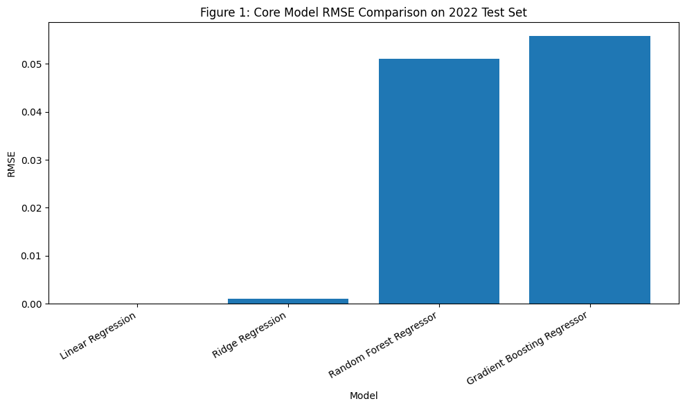

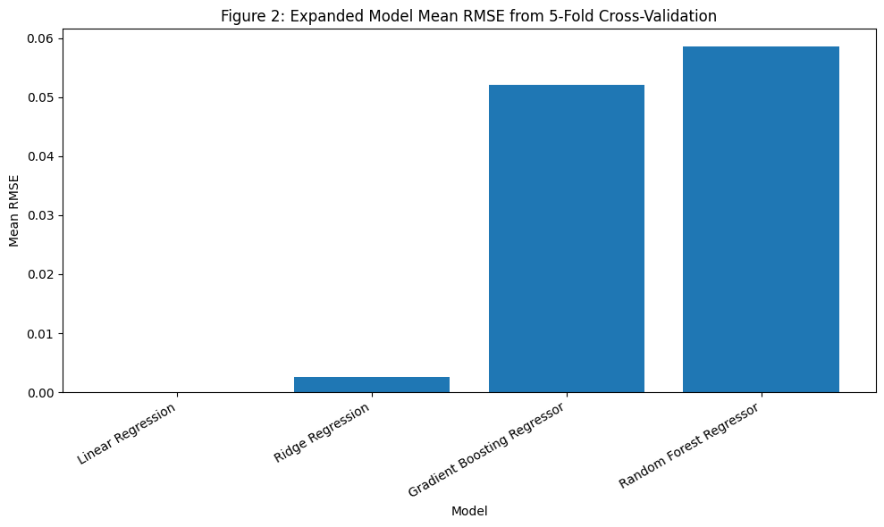

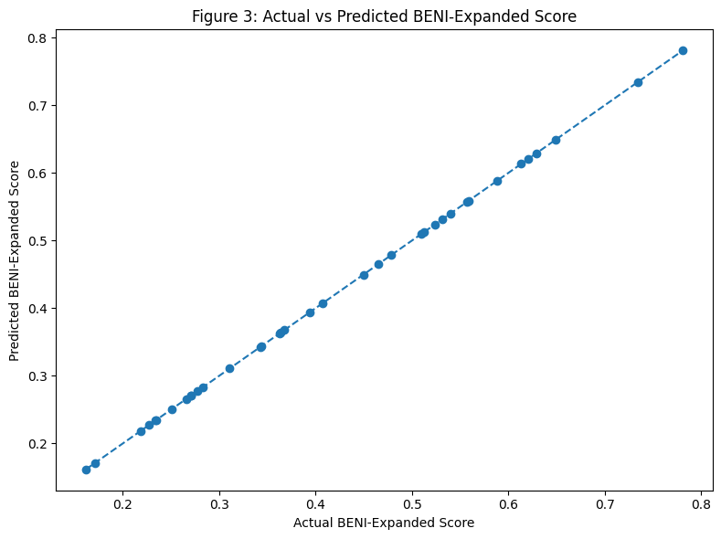

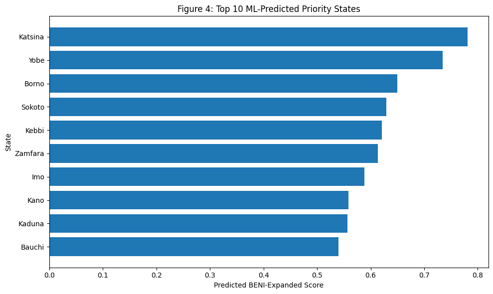

```
The best expanded model does not provide feature_importances_. Feature importance chart was skipped. This usually happens when Linear Regression or Ridge Regression is the best model.
Block 9 completed successfully.
Saved figures:
- figure_1_core_model_rmse_comparison.png
- figure_2_expanded_model_cv_rmse_comparison.png
- figure_3_actual_vs_predicted_beni_expanded.png
- figure_4_top10_ml_predicted_priority_states.png

Saved tables:
- core_model_performance_results.csv
- expanded_model_cv_performance_results.csv
- expanded_beni_ml_ranking_comparison.csv
```

```python
# ============================================================
# STAGE ML-2: MACHINE LEARNING MODEL DEVELOPMENT
# BLOCK 9: CREATE VISUALIZATIONS FOR MODEL RESULTS
# ============================================================

# ------------------------------------------------------------
# 1. Create a folder for saving model figures.
# ------------------------------------------------------------

# Import os for folder creation and file-path handling.
import os

# Define the folder where figures will be saved.
figures_dir = "ml_model_figures"

# Create the folder if it does not already exist.
os.makedirs(figures_dir, exist_ok=True)

# Confirm folder creation.
print(f"Figures will be saved in: {figures_dir}")


# ------------------------------------------------------------
# 2. Figure 1: Core model RMSE comparison.
# ------------------------------------------------------------

# Create a new figure for core model RMSE comparison.
plt.figure(figsize=(10, 6))

# Plot model names against RMSE values.
plt.bar(core_results_df["Model"], core_results_df["RMSE"])

# Add chart title.
plt.title("Figure 1: Core Model RMSE Comparison on 2022 Test Set")

# Add x-axis label.
plt.xlabel("Model")

# Add y-axis label.
plt.ylabel("RMSE")

# Rotate x-axis labels for readability.
plt.xticks(rotation=30, ha="right")

# Improve spacing.
plt.tight_layout()

# Save the figure.
plt.savefig(f"{figures_dir}/figure_1_core_model_rmse_comparison.png", dpi=300)

# Display the figure.
plt.show()


# ------------------------------------------------------------
# 3. Figure 2: Expanded model cross-validation RMSE comparison.
# ------------------------------------------------------------

# Create a new figure for expanded model RMSE comparison.
plt.figure(figsize=(10, 6))

# Plot model names against mean cross-validation RMSE.
plt.bar(expanded_results_df["Model"], expanded_results_df["Mean_RMSE"])

# Add chart title.
plt.title("Figure 2: Expanded Model Mean RMSE from 5-Fold Cross-Validation")

# Add x-axis label.
plt.xlabel("Model")

# Add y-axis label.
plt.ylabel("Mean RMSE")

# Rotate x-axis labels for readability.
plt.xticks(rotation=30, ha="right")

# Improve spacing.
plt.tight_layout()

# Save the figure.
plt.savefig(f"{figures_dir}/figure_2_expanded_model_cv_rmse_comparison.png", dpi=300)

# Display the figure.
plt.show()


# ------------------------------------------------------------
# 4. Figure 3: Actual vs predicted BENI-Expanded score.
# ------------------------------------------------------------

# Create a new figure for actual versus predicted BENI-Expanded scores.
plt.figure(figsize=(8, 6))

# Plot actual BENI-Expanded score against predicted BENI-Expanded score.
plt.scatter(
    expanded_predictions["actual_beni_expanded_score"],
    expanded_predictions["predicted_beni_expanded_score"]
)

# Calculate the minimum value for the reference line.
min_score = min(
    expanded_predictions["actual_beni_expanded_score"].min(),
    expanded_predictions["predicted_beni_expanded_score"].min()
)

# Calculate the maximum value for the reference line.
max_score = max(
    expanded_predictions["actual_beni_expanded_score"].max(),
    expanded_predictions["predicted_beni_expanded_score"].max()
)

# Add a diagonal reference line showing perfect prediction.
plt.plot([min_score, max_score], [min_score, max_score], linestyle="--")

# Add chart title.
plt.title("Figure 3: Actual vs Predicted BENI-Expanded Score")

# Add x-axis label.
plt.xlabel("Actual BENI-Expanded Score")

# Add y-axis label.
plt.ylabel("Predicted BENI-Expanded Score")

# Improve spacing.
plt.tight_layout()

# Save the figure.
plt.savefig(f"{figures_dir}/figure_3_actual_vs_predicted_beni_expanded.png", dpi=300)

# Display the figure.
plt.show()


# ------------------------------------------------------------
# 5. Figure 4: Top 10 ML-predicted priority states.
# ------------------------------------------------------------

# Select the top 10 states by ML-predicted priority rank.
top10_ml_priority = expanded_predictions.sort_values(
    by="ml_predicted_rank",
    ascending=True
).head(10).copy()

# Sort for horizontal plotting.
top10_ml_priority = top10_ml_priority.sort_values(
    by="predicted_beni_expanded_score",
    ascending=True
)

# Create a new figure for top 10 ML-predicted priority states.
plt.figure(figsize=(10, 6))

# Plot states against predicted BENI-Expanded score.
plt.barh(
    top10_ml_priority["state"],
    top10_ml_priority["predicted_beni_expanded_score"]
)

# Add chart title.
plt.title("Figure 4: Top 10 ML-Predicted Priority States")

# Add x-axis label.
plt.xlabel("Predicted BENI-Expanded Score")

# Add y-axis label.
plt.ylabel("State")

# Improve spacing.
plt.tight_layout()

# Save the figure.
plt.savefig(f"{figures_dir}/figure_4_top10_ml_predicted_priority_states.png", dpi=300)

# Display the figure.
plt.show()


# ------------------------------------------------------------
# 6. Figure 5: Feature importance from best expanded tree-based model.
# ------------------------------------------------------------

# Define a helper function to extract feature importance from a model.
def get_feature_importance(model, feature_names):
    """
    Extracts feature importance from tree-based models.
    Returns None if the selected model does not support feature_importances_.
    """

    # If the model is a Pipeline, get the final model step.
    if isinstance(model, Pipeline):
        final_model = model.named_steps["model"]
    else:
        final_model = model

    # Check whether the final model has feature_importances_.
    if hasattr(final_model, "feature_importances_"):
        return pd.DataFrame({
            "feature": feature_names,
            "importance": final_model.feature_importances_
        }).sort_values(by="importance", ascending=False)

    # Return None if feature importance is not available.
    return None


# Extract feature importance from the best expanded model.
expanded_feature_importance = get_feature_importance(
    best_expanded_model,
    expanded_features_available
)

# Check whether feature importance is available.
if expanded_feature_importance is not None:

    # Sort feature importance for horizontal plotting.
    feature_importance_plot_df = expanded_feature_importance.sort_values(
        by="importance",
        ascending=True
    )

    # Create a new figure for feature importance.
    plt.figure(figsize=(10, 6))

    # Plot feature importance.
    plt.barh(
        feature_importance_plot_df["feature"],
        feature_importance_plot_df["importance"]
    )

    # Add chart title.
    plt.title("Figure 5: Feature Importance from Best Expanded Model")

    # Add x-axis label.
    plt.xlabel("Importance")

    # Add y-axis label.
    plt.ylabel("Feature")

    # Improve spacing.
    plt.tight_layout()

    # Save the figure.
    plt.savefig(f"{figures_dir}/figure_5_expanded_model_feature_importance.png", dpi=300)

    # Display the figure.
    plt.show()

    # Display the feature-importance table.
    print("Expanded model feature importance:")
    display(expanded_feature_importance)

else:

    # Display a message if the best expanded model does not support feature importance.
    print(
        "The best expanded model does not provide feature_importances_. "
        "Feature importance chart was skipped. "
        "This usually happens when Linear Regression or Ridge Regression is the best model."
    )


# ------------------------------------------------------------
# 7. Save model result tables as CSV files.
# ------------------------------------------------------------

# Save core model results.
core_results_df.to_csv("core_model_performance_results.csv", index=False)

# Save expanded model results.
expanded_results_df.to_csv("expanded_model_cv_performance_results.csv", index=False)

# Save expanded ranking comparison.
expanded_ranking_comparison.to_csv("expanded_beni_ml_ranking_comparison.csv", index=False)

# Save feature importance if available.
if expanded_feature_importance is not None:
    expanded_feature_importance.to_csv("expanded_model_feature_importance.csv", index=False)


# ------------------------------------------------------------
# 8. Display saved output confirmation.
# ------------------------------------------------------------

print("Block 9 completed successfully.")
print("Saved figures:")
print("- figure_1_core_model_rmse_comparison.png")
print("- figure_2_expanded_model_cv_rmse_comparison.png")
print("- figure_3_actual_vs_predicted_beni_expanded.png")
print("- figure_4_top10_ml_predicted_priority_states.png")

if expanded_feature_importance is not None:
    print("- figure_5_expanded_model_feature_importance.png")

print("\nSaved tables:")
print("- core_model_performance_results.csv")
print("- expanded_model_cv_performance_results.csv")
print("- expanded_beni_ml_ranking_comparison.csv")

if expanded_feature_importance is not None:
    print("- expanded_model_feature_importance.csv")
```

Block Result Reviewed: Block 9 Visualizations

The visualization block ran successfully, and the charts are useful for the Interim Report. They directly strengthen the weakest part of the draft report: actual visual evidence and interpretation.

Overall Assessment

These four figures are suitable for the report, but the captions must be written carefully because the Linear Regression results are almost perfect due to the engineered BENI target.

The figures should be used as model validation and ranking-consistency evidence, not as evidence of independent causal prediction.

Figure-by-Figure Evaluation Figure 1: Core Model RMSE Comparison on 2022 Test Set

This figure is useful. It shows that Linear Regression and Ridge Regression have the lowest RMSE, while Random Forest and Gradient Boosting have higher RMSE.

Interpretation for report:

Figure 1 compares the RMSE of four models used to estimate BENI-Core on the 2022 holdout set. Linear Regression produced the lowest error because BENI-Core is a transparent composite index derived from the same core indicators used as predictors. Ridge Regression produced similarly low error, while Random Forest and Gradient Boosting had higher error but still provided useful nonlinear robustness checks.

Recommendation: Keep this figure.

Figure 2: Expanded Model Mean RMSE from 5-Fold Cross-Validation

This figure is also useful. It shows that Linear Regression and Ridge Regression again perform best, while tree-based models perform less strongly.

Interpretation for report:

Figure 2 shows the 5-fold cross-validation RMSE for the expanded 2022 model. Linear Regression achieved near-zero error, followed closely by Ridge Regression. This confirms that BENI-Expanded is mathematically reproducible from its component education and socioeconomic indicators. The tree-based models had higher error but still maintained reasonable fit, indicating that nonlinear methods can approximate the same prioritization pattern.

Recommendation: Keep this figure.

Figure 3: Actual vs Predicted BENI-Expanded Score

This is one of the strongest visualizations. The points lie almost perfectly on the diagonal line.

Interpretation for report:

Figure 3 shows the relationship between actual BENI-Expanded scores and model-predicted BENI-Expanded scores. The near-perfect diagonal alignment indicates that the model reproduced the engineered BENI-Expanded score. Since BENI-Expanded was constructed from the same indicators used as model inputs, this result confirms reproducibility and internal consistency rather than independent causal prediction.

Recommendation: Keep this figure, but make sure the caption includes the caution above.

Figure 4: Top 10 ML-Predicted Priority States

This is highly useful for the Preliminary Results section. It gives the report a clear policy-facing output.

Top 10 ML-predicted priority states:

Katsina Yobe Borno Sokoto Kebbi Zamfara Imo Kano Kaduna Bauchi

Interpretation for report:

Figure 4 presents the top 10 states identified by the ML-predicted BENI-Expanded score. Katsina, Yobe, Borno, Sokoto, Kebbi, and Zamfara appear among the highest-priority states, indicating that the model assigns greatest need to states with stronger combined education-infrastructure pressure and socioeconomic disadvantage. The same top 10 states were recovered by both the actual BENI-Expanded ranking and the model-predicted ranking, producing a 100% top-10 overlap.

Recommendation: Keep this figure. It is important for the report’s results section.

Important Issue: Missing Feature Importance Chart

Block 9 was expected to generate a feature-importance figure only if the best expanded model was tree-based. Since the best expanded model is Linear Regression, the feature-importance chart was likely skipped.

That is acceptable, but for the report, it would be useful to add one more figure showing coefficient importance from Linear Regression or Ridge Regression.

```
Linear Regression coefficient importance for BENI-Expanded:
```

|  | feature | coefficient | absolute_coefficient |
| --- | --- | --- | --- |
| 2 | unqualified_teacher_share | 0.049698 | 0.049698 |
| 4 | enrolment_per_school | 0.040042 | 0.040042 |
| 5 | nbs_socioeconomic_need_proxy | 0.039847 | 0.039847 |
| 1 | pupil_classroom_ratio | 0.038092 | 0.038092 |
| 0 | pupil_teacher_ratio | 0.037175 | 0.037175 |
| 3 | bad_classroom_share | 0.036963 | 0.036963 |

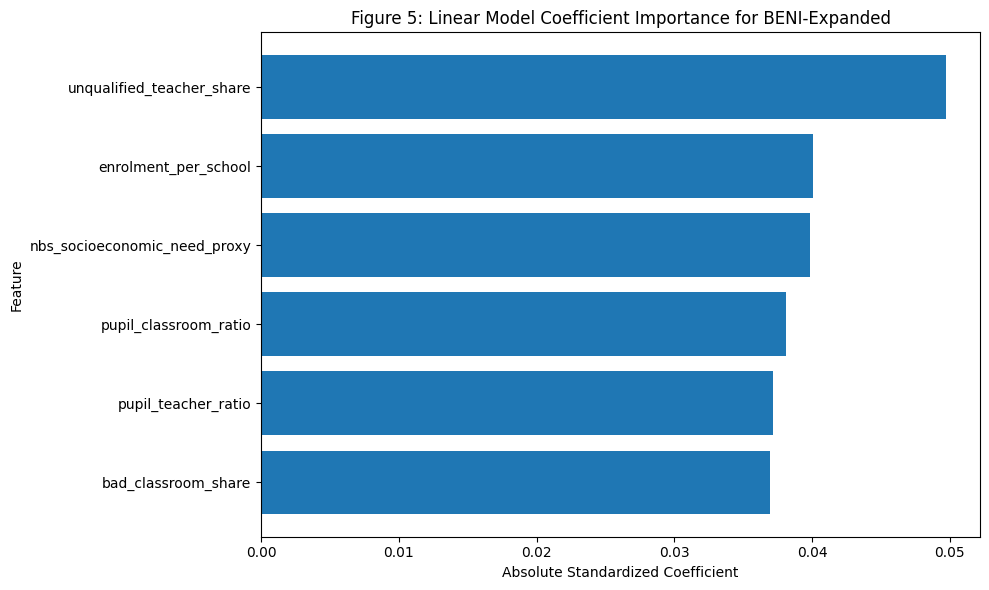

```python
# ============================================================
# STAGE ML-2: MACHINE LEARNING MODEL DEVELOPMENT
# BLOCK 9B: LINEAR MODEL COEFFICIENT IMPORTANCE
# ============================================================

# Create a fresh Linear Regression pipeline for coefficient extraction.
linear_expanded_model = Pipeline(steps=[
    ("scaler", StandardScaler()),
    ("model", LinearRegression())
])

# Fit the Linear Regression model on all expanded data.
linear_expanded_model.fit(X_expanded, y_expanded)

# Extract coefficients from the fitted linear model.
linear_coefficients = linear_expanded_model.named_steps["model"].coef_

# Create coefficient importance dataframe.
linear_coefficient_importance = pd.DataFrame({
    "feature": expanded_features_available,
    "coefficient": linear_coefficients,
    "absolute_coefficient": np.abs(linear_coefficients)
}).sort_values(by="absolute_coefficient", ascending=False)

# Display coefficient importance table.
print("Linear Regression coefficient importance for BENI-Expanded:")
display(linear_coefficient_importance)

# Sort values for horizontal plotting.
coef_plot_df = linear_coefficient_importance.sort_values(
    by="absolute_coefficient",
    ascending=True
)

# Create coefficient importance figure.
plt.figure(figsize=(10, 6))

# Plot absolute coefficient values.
plt.barh(
    coef_plot_df["feature"],
    coef_plot_df["absolute_coefficient"]
)

# Add title.
plt.title("Figure 5: Linear Model Coefficient Importance for BENI-Expanded")

# Add x-axis label.
plt.xlabel("Absolute Standardized Coefficient")

# Add y-axis label.
plt.ylabel("Feature")

# Improve layout.
plt.tight_layout()

# Save the figure.
plt.savefig(
    f"{figures_dir}/figure_5_linear_coefficient_importance_beni_expanded.png",
    dpi=300
)

# Display the figure.
plt.show()
```

## Block Result Reviewed: Block 9B Linear Coefficient Importance

This block ran **successfully**, and the output is very useful for the **Modelling** and **Preliminary Results** sections.

## Key Result

The coefficient-importance ranking is:

| Rank | Feature | Coefficient |
| --- | --- | --- |
| 1 | `unqualified_teacher_share` | 0.049698 |
| 2 | `enrolment_per_school` | 0.040042 |
| 3 | `nbs_socioeconomic_need_proxy` | 0.039847 |
| 4 | `pupil_classroom_ratio` | 0.038092 |
| 5 | `pupil_teacher_ratio` | 0.037175 |
| 6 | `bad_classroom_share` | 0.036963 |

## Interpretation

This is a strong and balanced result. It shows that all six variables contribute positively to the BENI-Expanded score, which is exactly what we expect because higher values represent greater need.

The most influential predictor is **unqualified teacher share**, followed by **enrolment per school** and the **NBS socioeconomic need proxy**. This suggests that the expanded need score is not driven only by physical classroom pressure; it also reflects teacher-quality pressure, school-stock pressure, and socioeconomic disadvantage.

## Best Report Wording

Use this in the report:

> Figure 5 presents standardized coefficient importance from the Linear Regression model used to reconstruct BENI-Expanded. All predictors have positive coefficients, confirming that each indicator contributes in the expected direction to the need score. The strongest coefficient is for unqualified teacher share, followed by enrolment per school and the NBS socioeconomic need proxy. This indicates that teacher-quality pressure, school-stock pressure, and socioeconomic disadvantage are among the most influential components in the expanded prioritization framework.

## A+ Methodological Note

Because BENI-Expanded is an engineered composite index, coefficient importance should be interpreted as **index contribution**, not causal importance.

Do not say:

> Unqualified teacher share causes infrastructure need more than other variables.

Say:

> Unqualified teacher share contributes most strongly to the model’s reconstruction of the BENI-Expanded score.

## Recommendation

Proceed to **Block 10: Export All Model Outputs to a Single Excel Workbook**.

After Block 10, we will have the complete model-result workbook for GitHub, appendix evidence, and interim-report tables.

```python
# ============================================================
# STAGE ML-2: MACHINE LEARNING MODEL DEVELOPMENT
# BLOCK 10: EXPORT MODEL OUTPUTS TO A SINGLE EXCEL WORKBOOK
# ============================================================

# ------------------------------------------------------------
# 1. Define output Excel workbook name.
# ------------------------------------------------------------

output_excel_file = "Capstone_ML_Model_Results_Workbook.xlsx"


# ------------------------------------------------------------
# 2. Create a compact modelling summary table.
# ------------------------------------------------------------

ml_summary = pd.DataFrame({
    "Item": [
        "Core model target",
        "Expanded model target",
        "Core model training rows",
        "Core model test rows",
        "Expanded model rows",
        "Core feature count",
        "Expanded feature count",
        "Best core model by RMSE",
        "Best expanded model by Mean RMSE",
        "Expanded rank correlation",
        "Expanded top-10 overlap count",
        "Expanded top-10 overlap rate"
    ],
    "Value": [
        core_target,
        expanded_target,
        X_core_train.shape[0],
        X_core_test.shape[0],
        X_expanded.shape[0],
        X_core_train.shape[1],
        X_expanded.shape[1],
        best_core_model_name,
        best_expanded_model_name,
        round(rank_corr, 4),
        top10_overlap_count,
        f"{top10_overlap_rate:.2%}"
    ]
})


# ------------------------------------------------------------
# 3. Create a core feature list table.
# ------------------------------------------------------------

core_feature_table = pd.DataFrame({
    "Feature": core_features_available,
    "Model_Use": "BENI-Core prediction",
    "Feature_Type": "Education / infrastructure"
})


# ------------------------------------------------------------
# 4. Create an expanded feature list table.
# ------------------------------------------------------------

expanded_feature_table = pd.DataFrame({
    "Feature": expanded_features_available,
    "Model_Use": "BENI-Expanded prediction",
    "Feature_Type": [
        "Socioeconomic need proxy" if "nbs" in feature.lower()
        else "Education / infrastructure"
        for feature in expanded_features_available
    ]
})


# ------------------------------------------------------------
# 5. Create top 10 actual BENI priority table.
# ------------------------------------------------------------

top10_actual_beni = expanded_ranking_comparison.sort_values(
    by="actual_beni_rank",
    ascending=True
).head(10).copy()


# ------------------------------------------------------------
# 6. Create top 10 ML-predicted priority table.
# ------------------------------------------------------------

top10_ml_predicted = expanded_ranking_comparison.sort_values(
    by="ml_predicted_rank",
    ascending=True
).head(10).copy()


# ------------------------------------------------------------
# 7. Create a short interpretation table for report writing.
# ------------------------------------------------------------

interpretation_notes = pd.DataFrame({
    "Output": [
        "Core model performance",
        "Expanded model performance",
        "Rank correlation",
        "Top-10 overlap",
        "Linear coefficient importance",
        "Policy interpretation"
    ],
    "Interpretation": [
        "The core models test whether UBEC-derived education and infrastructure features can estimate BENI-Core scores on the 2022 holdout set.",
        "The expanded models test whether UBEC indicators plus the NBS socioeconomic need proxy can estimate BENI-Expanded scores under 5-fold cross-validation.",
        "Spearman rank correlation measures whether the model preserves the priority order of states, which is important because the project is a prioritization problem.",
        "Top-10 overlap measures whether the model identifies the same high-priority states as the BENI-Expanded index.",
        "Linear coefficient importance shows the relative contribution of each standardized predictor to reconstructing BENI-Expanded.",
        "The machine-learning models are supplementary validation tools; BENI remains the primary transparent decision-support index."
    ]
})


# ------------------------------------------------------------
# 8. Export all outputs into a single Excel workbook.
# ------------------------------------------------------------

with pd.ExcelWriter(output_excel_file, engine="openpyxl") as writer:

    # Write summary sheet.
    ml_summary.to_excel(writer, sheet_name="ML_Summary", index=False)

    # Write core model performance.
    core_results_df.to_excel(writer, sheet_name="Core_Model_Performance", index=False)

    # Write expanded model performance.
    expanded_results_df.to_excel(writer, sheet_name="Expanded_CV_Performance", index=False)

    # Write core predictions.
    core_predictions.to_excel(writer, sheet_name="Core_2022_Predictions", index=False)

    # Write expanded ranking comparison.
    expanded_ranking_comparison.to_excel(writer, sheet_name="Expanded_Rank_Comparison", index=False)

    # Write top 10 actual BENI priorities.
    top10_actual_beni.to_excel(writer, sheet_name="Top10_Actual_BENI", index=False)

    # Write top 10 ML-predicted priorities.
    top10_ml_predicted.to_excel(writer, sheet_name="Top10_ML_Predicted", index=False)

    # Write core feature list.
    core_feature_table.to_excel(writer, sheet_name="Core_Features", index=False)

    # Write expanded feature list.
    expanded_feature_table.to_excel(writer, sheet_name="Expanded_Features", index=False)

    # Write interpretation notes.
    interpretation_notes.to_excel(writer, sheet_name="Interpretation_Notes", index=False)

    # Write linear coefficient importance if available.
    if "linear_coefficient_importance" in globals():
        linear_coefficient_importance.to_excel(
            writer,
            sheet_name="Linear_Coefficients",
            index=False
        )

    # Write tree-based feature importance if available from earlier block.
    if "expanded_feature_importance" in globals() and expanded_feature_importance is not None:
        expanded_feature_importance.to_excel(
            writer,
            sheet_name="Tree_Feature_Importance",
            index=False
        )


# ------------------------------------------------------------
# 9. Display confirmation and download the workbook.
# ------------------------------------------------------------

print("Block 10 completed successfully.")
print(f"Excel workbook created: {output_excel_file}")

# Download the Excel workbook from Colab.
files.download(output_excel_file)
```

```
Block 10 completed successfully.
Excel workbook created: Capstone_ML_Model_Results_Workbook.xlsx
```